# Research Methods and Communication Workshop 2: Analysing Frequencies

Rob Knell

## 1 Fish parasitism and predator avoidance

Here are some data from an experiment looking at the relationship between parasitism of roach (*Rutilus rutilus*) on their predator avoidance behaviour. Fish were separated into those with and without infection by the tapeworm *Ligula intestinalis* by x-raying them. *L. intestinalis* has a complex life cycle with the adult worm in fish eating bird hosts and it has been suggested that the parasite might reduce avoidance behaviour in infected hosts in order to increase the probability of the host being eaten by a suitable host for the parasite. To test this, each individual fish was placed in a separate tank and tested by “flying” a silhouette of a predatory bird on a wire over the tank, and the fish were scored as to whether they showed avoidance behaviour or not. The table below shows the number of fish that were scored in each category.

|  | Unparasitised | Parasitised |
| --- | --- | --- |
| **Avoidance behaviour** | 33 | 24 |
| **No avoidance behaviour** | 17 | 26 |

1. Input the data into R as a 2x2 matrix. Use the rownames() and colnames() functions to name the columns and rows.
2. Draw a barplot of the data using the barplot() function. Include a legend.
3. Carry out a chi square test for independence of data using the chisq.test() function.

### Questions

What is the null hypothesis?

What are the assumptions behind a chi square test? Do your data meet them?

What does the statistical test tell you?

## 2a Comparing female patients with and without lung cancer

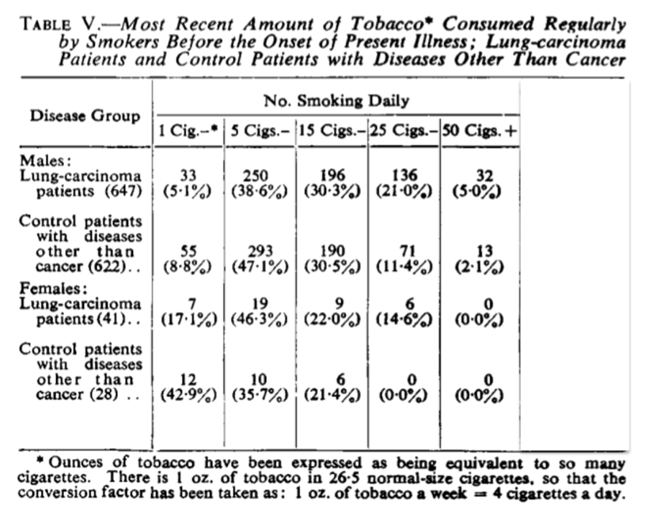

The table above is taken from the Doll and Hill (1950) paper on smoking rates and lung cancer in patients in London. The data give self-reported smoking rates for male and female patients who were classified as smokers in the study. Data are given separately for lung cancer patients and for patients with other illnesses that were matched to the lung cancer patients by age and sex. You have already seen an analysis of the data for male patients in the tutorial, and this analysis is detailed in the chapter of “Introductory R” entitled “Analysing frequencies”.

1. Draw a bar graph showing the numbers of cigarettes smoked by female patients with and without lung cancer. What do you see?
2. Carry out a statistical test of the hypothesis that there is no difference in the frequency of smoking different numbers of cigarettes between female lung cancer and female control patients. NB think carefully about whether you want to use the data exactly as presented here or whether it makes sense to change the categories of numbers of cigarettes smoked for this analysis.

## 2b Comparing smoking rates in female patients

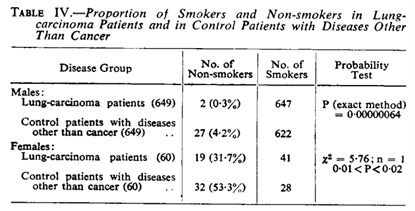

This table, also from the Doll and Hill (1950) paper shows the numbers of smokers and non-smokers in the study from the lung cancer and control groups. You’ve already seen the analysis of smoking rates in male patients.

1. Using an appropriate statistical test, evaluate the hypothesis that smoking rates are the same in male and female control patients.
2. Compare the reported smoking rates in female patients with and without lung cancer. NB Doll and Hill used a Fisher’s exact test for this analysis on male patients, as explained in the book. Is it necessary to use this test for the female data, or could you use a normal chi-square test?

### Questions

You now have an analysis of the data on smoking and lung cancer in female patients. Can you answer the following questions?

1. How are the results for women different from the results for men?
2. What are the likely reasons for any differences between the results for women and the results for men?
3. On the basis of these results and your analysis, how well supported is the idea that smoking is linked to lung cancer in women?